# Getting started with epiworldR

Derek Meyer

George Vega Yon

Andrew Pulsipher

2026-03-26

epiworldR is an R package that provides a fast (C++ backend) and highly- customizable framework for building network-based transmission/diffusion agent- based models [ABM]. Some key features of epiworldR are the ability to construct multi-virus models (e.g., models of competing multi-pathogens/multi-rumor,) design mutating pathogens, architect population-level interventions, and build models with an arbitrary number of compartments/states (beyond SIR/SEIR.)

# Example 1: Simulating an SIR model

## Setup and running the model

```r
library(epiworldR)
model_sir <- ModelSIRCONN(
  name              = "COVID-19",
  n                 = 50000,
  prevalence        = 0.0001,
  contact_rate      = 2,
  transmission_rate = 0.5,
  recovery_rate     = 1 / 3
)

# Printing the model
model_sir
```

```
________________________________________________________________________________
Susceptible-Infected-Removed (SIR) (connected)
It features 50000 agents, 1 virus(es), and 0 tool(s).
The model has 3 states. The model hasn't been run yet.
```

Printing the model shows us some information. Nevertheless, we can extract detailed information using the summary method.

```r
summary(model_sir)
```

```
________________________________________________________________________________
________________________________________________________________________________
SIMULATION STUDY

Name of the model   : Susceptible-Infected-Removed (SIR) (connected)
Population size     : 50000
Agents' data        : (none)
Number of entities  : 0
Days (duration)     : 0 (of 0)
Number of viruses   : 1
Last run elapsed t  : -
Rewiring            : off
Last seed used      : 0

Global events:
 - Update infected individuals (runs daily)

Virus(es):
 - COVID-19

Tool(s):
 (none)

Model parameters:
 - Contact rate      : 2.0000
 - Recovery rate     : 0.3333
 - Transmission rate : 0.5000
```

First, the name of the model, population size, number of entities (think of these as public spaces in which agents can make social contact with one another), the duration in days, number of viruses, amount of time the last replicate took to run (last run elapsed t), and rewiring status (on or off). The model also includes a list of global actions (interventions) that are called during the model run. Next, you will see a list of the viruses used in the model. In this case, COVID-19 was the only virus used. Note that epiworldR can include more than one virus in a model. Tool(s) lists agents’ tools to fight the virus. Examples of this may include masking, vaccines, social distancing, etc. In this model, no tools are specified. Lastly, model parameters are listed.

To execute the model, use the run function with the SIR model object, the number of simulation days, and an optional seed for reproducibility. Next, print out the results from the simulated model using model_sir.

```r
run(model_sir, ndays = 50, seed = 1912)
```

```
_________________________________________________________________________
|Running the model...
|||||||||||||||||||||||||||||||||||||||||||||||||||||||||||||||||||||||| done.
```

```r
summary(model_sir)
```

```
________________________________________________________________________________
________________________________________________________________________________
SIMULATION STUDY

Name of the model   : Susceptible-Infected-Removed (SIR) (connected)
Population size     : 50000
Agents' data        : (none)
Number of entities  : 0
Days (duration)     : 50 (of 50)
Number of viruses   : 1
Last run elapsed t  : 84.00ms
Last run speed      : 29.59 million agents x day / second
Rewiring            : off
Last seed used      : 1912

Global events:
 - Update infected individuals (runs daily)

Virus(es):
 - COVID-19

Tool(s):
 (none)

Model parameters:
 - Contact rate      : 2.0000
 - Recovery rate     : 0.3333
 - Transmission rate : 0.5000

Distribution of the population at time 50:
  - (0) Susceptible : 49995 -> 3296
  - (1) Infected    :     5 -> 6
  - (2) Recovered   :     0 -> 46698

Transition Probabilities:
 - Susceptible  0.95  0.05     -
 - Infected        -  0.67  0.33
 - Recovered       -     -  1.00
```

There are two additional sections included in the summary after running the model. First, we see the distribution of the population at time 50. This section describes the flow of agents from each state (SIR) after 50 days. In the example, you’ll see the number of agents in the susceptible state decreased from 49,995 to 3,296, the number of agents in the infected state increased from 5 to 6, and recovered agents increased to 46,698 after 50 days. The counts for these states will change based on model parameters or simulation run-time. The transmission probabilities section outputs a 3x3 matrix that describes the probability of moving from one state to another. For example, in the susceptible row, each agent has a 0.95 probability of remaining in the susceptible state with a 0.05 probability of moving from the susceptible state to the infected state. Notice there is no chance of skipping states. In other words, an agent can’t jump from the susceptible state to the recovered state; that agent must pass through the infected state to progress to the recovered state. The same logic applies to moving backward; an agent cannot become susceptible again after infection.

## Plot

To make a mermaid diagram of the model states and transition probabilities, use the `draw_mermaid()` function. By default, we can print the diagram to the console like this:

```r
diagram <- draw_mermaid(model_sir)
print(diagram)
```

```
flowchart TB
    s0[Infected]
    s1[Recovered]
    s2[Susceptible]
    s0 -->|0.333562| s1
    s2 -->|0.045033| s0
```

If the `DiagrammeR` package is installed, we can visualize the diagram directly in R:

```r
plot(diagram)
```

[interactive chart not shown]

## Extracting information

After running the epiworldR model, below is a list of all the functions that can be called using the epiworld model object.

```r
methods(class = "epiworld_model")
```

```
 [1] add_param                  add_tool
 [3] add_virus                  agents_from_edgelist
 [5] agents_smallworld          get_agents
 [7] get_hist_tool              get_hist_total
 [9] get_hist_transition_matrix get_hist_virus
[11] get_n_replicates           get_n_tools
[13] get_n_viruses              get_name
[15] get_ndays                  get_param
[17] get_reproductive_number    get_states
[19] get_today_total            get_transition_probability
[21] get_transmissions          plot
[23] print                      queuing_off
[25] queuing_on                 run
[27] run_multiple               set_name
[29] set_param                  size
[31] summary                    today
[33] verbose_off                verbose_on
see '?methods' for accessing help and source code
```

To demonstrate, start with the basic plot and get_hist_total functions.

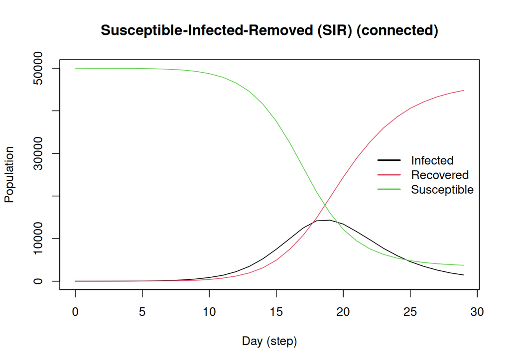

```r
plot(model_sir)
```

As evident from the above plot, the SIR model constructed from epiworldR displays the changes in susceptible, infected, and recovered case counts over time (days). Notice after a certain amount of time, the curves flatten. Below, a table representation of the above plot is printed, complete with each state within the SIR model, date, and agent counts.

```r
head(get_hist_total(model_sir))
```

```
  date       state counts
1    0 Susceptible  49995
2    0    Infected      5
3    0   Recovered      0
4    1 Susceptible  49987
5    1    Infected      9
6    1   Recovered      4
```

An essential statistic in epidemiological models is the reproductive number:

```r
repnum <- get_reproductive_number(model_sir)
head(repnum)
```

```
  virus_id    virus source source_exposure_date rt
1        0 COVID-19   6601                   47  0
2        0 COVID-19  26391                   44  0
3        0 COVID-19  48144                   43  0
4        0 COVID-19  39021                   43  0
5        0 COVID-19  44433                   42  0
6        0 COVID-19  38175                   42  0
```

epiworldR has a method to plot the reproductive number automatically. The function takes the average of values in the above table for each date and repeats until all data have been accounted for.

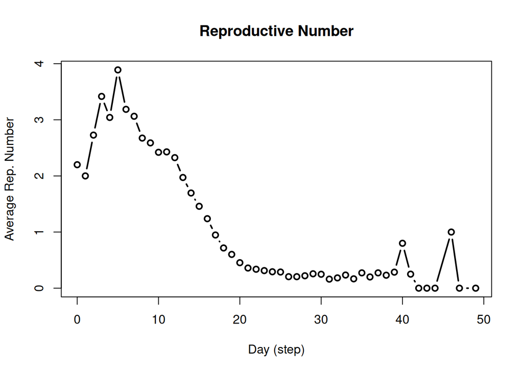

```r
x <- plot(repnum, type = "b")
```

```r
subset(x, date == 10) # Reproductive number on day 10
```

```
   virus_id    virus date      avg   n       sd lb ub
11        0 COVID-19   10 2.420956 544 2.189293  0  8
```

Another typical piece of information is the daily incidence. This is the number of new cases per day. In epiworldR, we can get the incidence by looking at the daily transitions between states. Although the function `get_hist_transition_matrix` provides the desired data, the function `plot_incidence` is a nice wrapper for visualizing the data:

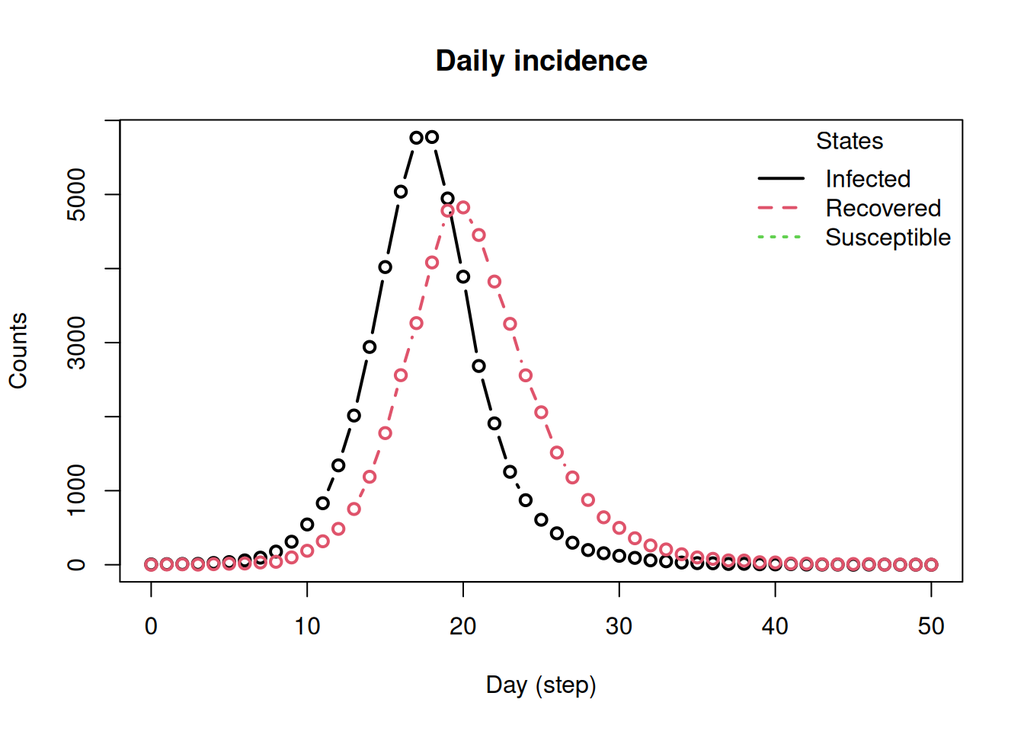

```r
plot_incidence(model_sir)
```

## Adding more viruses/viruses

```r
# Building the virus
flu <- virus(
  name = "Flu", prob_infecting = .3,
  prevalence = .0001, as_proportion = TRUE
)

# Adding the virus to the model
add_virus(model_sir, flu)
```

```r
run(model_sir, ndays = 50, seed = 1912)
```

```
_________________________________________________________________________
|Running the model...
|||||||||||||||||||||||||||||||||||||||||||||||||||||||||||||||||||||||| done.
```

```r
model_sir
```

```
________________________________________________________________________________
Susceptible-Infected-Removed (SIR) (connected)
It features 50000 agents, 2 virus(es), and 0 tool(s).
The model has 3 states.
The final distribution is: 3323 Susceptible, 2 Infected, and 46675 Recovered.
```

Plotting the previous model (including the flu) yields the following. Notice the presence of two reproductive numbers plotted over time. Variant 0 refers to COVID-19, and virus 1 refers to the flu.

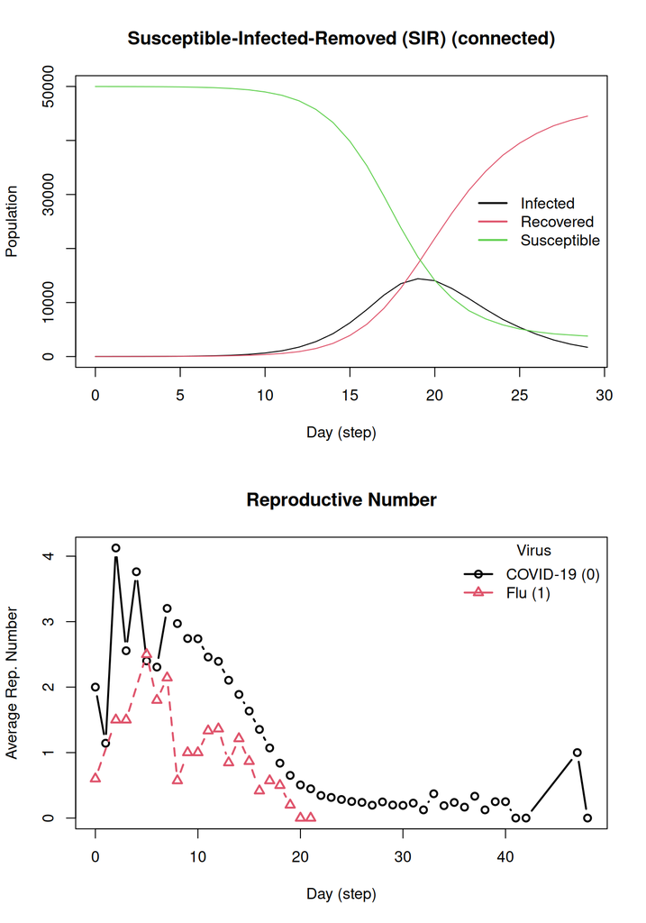

```r
repnum2 <- get_reproductive_number(model_sir)

op <- par(mfrow = c(2, 1))
plot(model_sir)
plot(repnum2, type = "b")
```

```r
par(op)
```

## Tools

```r
# Removing the flu virus from the model
rm_virus(model_sir, 1)

vaccine <- tool(
  name = "Vaccine",
  prevalence = 0.5,
  as_proportion = TRUE,
  susceptibility_reduction = .9,
  transmission_reduction = .5,
  recovery_enhancer = .5,
  death_reduction = .9
)

add_tool(model_sir, vaccine)
run(model_sir, ndays = 50, seed = 1231)
```

```
_________________________________________________________________________
|Running the model...
|||||||||||||||||||||||||||||||||||||||||||||||||||||||||||||||||||||||| done.
```

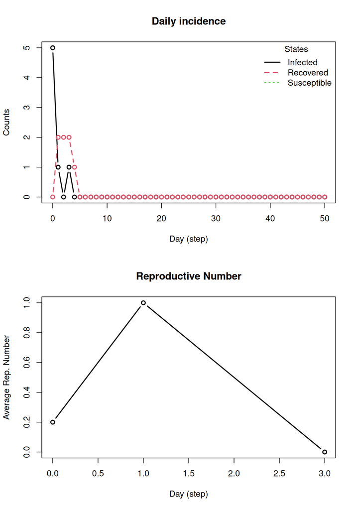

```r
repnum3 <- get_reproductive_number(model_sir)

op <- par(mfrow = c(2, 1))
plot_incidence(model_sir)
plot(repnum3, type = "b")
```

```r
par(op)
```